# Reproducible Research: Peer Assessment 1

## Loading and preprocessing the data

Set the working directory

```r
setwd("~/Documents/Coursera/05. Reproducible Research/Peer Assessment 1/RepData_PeerAssessment1")
```

Unzip the activity.zip file.

```r
unzip("./activity.zip")
```

The file activity.csv is saved in the same directory. Read the data

```r
data <- read.csv("activity.csv")
```

## What is mean total number of steps taken per day?

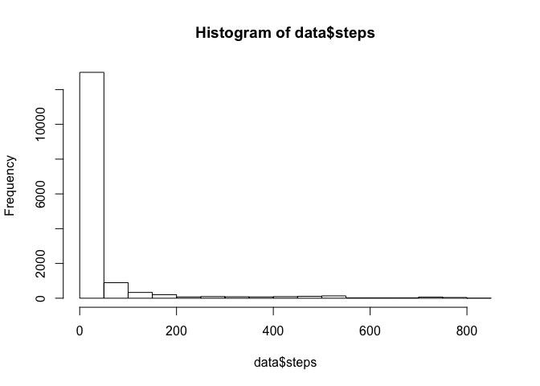

```r
hist(data$steps)
```

The plyr library is used to answer this question.

```r
library(plyr)
stepsperday <- ddply(data, .(date), summarize, totalsteps = sum(steps))
```

The mean total number of steps taken every day

```r
meanWithoutImputing <- mean(stepsperday$totalsteps, na.rm = TRUE)
print(meanWithoutImputing)
```

```
## [1] 10766.19
```

The median of the total number of steps taken every day

```r
medianWithoutImputing <- median(stepsperday$totalsteps, na.rm = TRUE)
print(medianWithoutImputing)
```

```
## [1] 10765
```

## What is the average daily activity pattern?

Calculate the average steps for each interval (missing values are omitted)

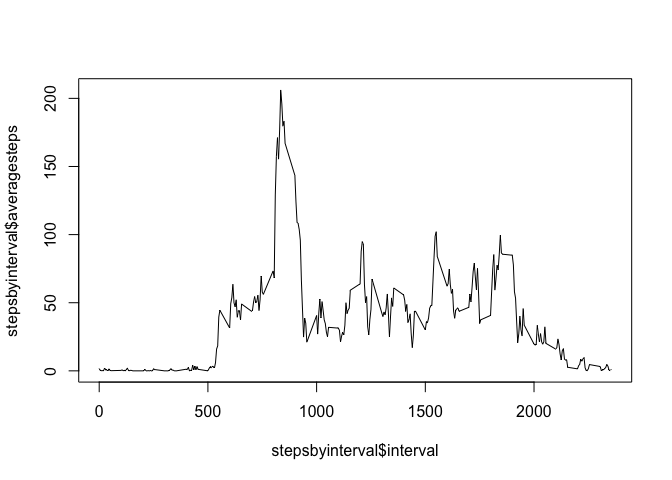

```r
library(ggplot2)
stepsbyinterval <- ddply(data, .(interval), summarize, averagesteps = mean(steps, na.rm = TRUE))
plot(stepsbyinterval$interval, stepsbyinterval$averagesteps,type = "l")
```

Which 5-minute interval, on average across all the days in the dataset, contains the maximum number of steps?

```r
with(stepsbyinterval, interval[averagesteps == max(stepsbyinterval$averagesteps)])
```

```
## [1] 835
```

## Imputing missing values

total number of missing values in the dataset (i.e. the total number of rows with NAs)

```r
sum(is.na(data$steps))
```

```
## [1] 2304
```

```r
sum(is.na(data$date))
```

```
## [1] 0
```

```r
sum(is.na(data$interval))
```

```
## [1] 0
```

Filling strategy: Replace the NA values with the average steps for that interval

```r
imputeddata <- data
missingsteps <- is.na(imputeddata$steps)

for (i in 1:length(missingsteps)) {
        if (missingsteps[i]) {
                imputeddata$steps[i] <-
                with(stepsbyinterval,
                     averagesteps[interval == imputeddata$interval[i]])
        }
}
```

Validate that imputeddata does not longer contain NA values

```r
sum(is.na(imputeddata$steps))
```

```
## [1] 0
```

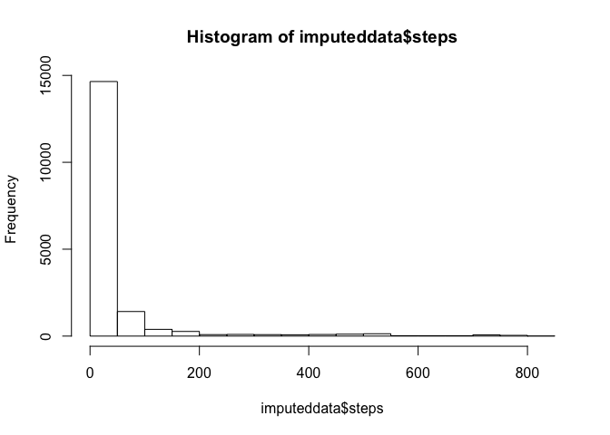

```r
hist(imputeddata$steps)
```

Mean and median total number of steps taken per day based on the imputed dataset

```r
stepsperdayimputed <- ddply(imputeddata, .(date), summarize, totalsteps = sum(steps))
```

The mean total number of steps taken every day

```r
meanWithImputing <- mean(stepsperdayimputed$totalsteps)
print(meanWithImputing)
```

```
## [1] 10766.19
```

The median of the total number of steps taken every day

```r
medianWithImputing <- median(stepsperdayimputed$totalsteps)
print(medianWithImputing)
```

```
## [1] 10766.19
```

#### What is the impact of imputing missing data on the estimates of the total daily number of steps?

Imputing did not change the mean but the median increased and became equal to the mean

## Are there differences in activity patterns between weekdays and weekends?

First add a new column with the weekday

```r
library(dplyr)
imputeddata <- mutate(imputeddata, DayType = weekdays(as.Date(date)))
```

Mark Monday, Tuesday, Wednesdday, Thursday, Friday as “weekday” and Saturday and Sunday as “weekend”

```r
imputeddata$DayType <- revalue(imputeddata$DayType, c("Monday" = "weekday",
                               "Tuesday" = "weekday",
                               "Wednesday" = "weekday",
                               "Thursday" = "weekday",
                               "Friday" = "weekday",
                               "Saturday" = "weekend",
                               "Sunday" = "weekend"
                               ))
```

Calculate average number of steps for weekend and weekdays

```r
avgNumberOfStepsByDayType <- ddply(imputeddata,
                                   .(DayType,interval),
                                   summarize,
                                   averagesteps = mean(steps, na.rm = TRUE))
```

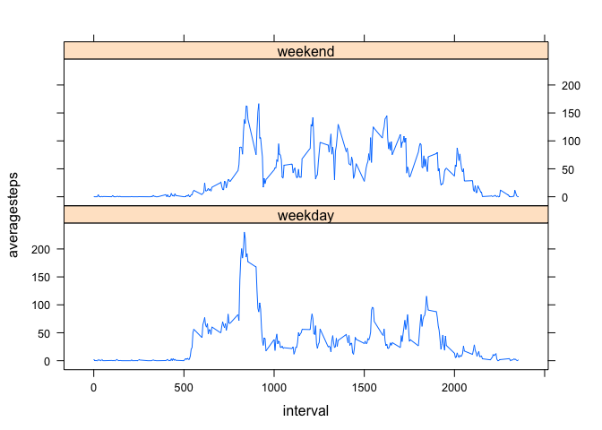

```r
library(lattice)
xyplot(averagesteps~interval | DayType ,
       avgNumberOfStepsByDayType,
       type = "l",
       layout = c(1,2))
```